# Human Activity Prediction

Aman Tiwari

14/09/2021

# Background

Using devices such as Jawbone Up, Nike FuelBand, and Fitbit it is now possible to collect a large amount of data about personal activity relatively inexpensively. These type of devices are part of the quantified self movement – a group of enthusiasts who take measurements about themselves regularly to improve their health, to find patterns in their behavior, or because they are tech geeks. One thing that people regularly do is quantify how much of a particular activity they do, but they rarely quantify how well they do it. In this project, your goal will be to use data from accelerometers on the belt, forearm, arm, and dumbell of 6 participants. They were asked to perform barbell lifts correctly and incorrectly in 5 different ways. More information is available from the website here: http://web.archive.org/web/20161224072740/http:/groupware.les.inf.puc-rio.br/har

# Data

The training data for this project are available here: https://d396qusza40orc.cloudfront.net/predmachlearn/pml-training.csv The test data are available here: https://d396qusza40orc.cloudfront.net/predmachlearn/pml-testing.csv The data for this project come from this source: http://web.archive.org/web/20161224072740/http:/groupware.les.inf.puc-rio.br/har.

# Goal

The goal of this project is to predict the manner in which they did the exercise. This is the “classe” variable in the training set. I may use any of the other variables to predict with. I should create a report describing how I built my model, how I used cross validation, what I think the expected out of sample error is, and why I made the choices I did. I will also use my prediction model to predict 20 different test cases.

# Loading packages and Data

```r
pacman::p_load(data.table, caret, parallel, doParallel, purrr, visdat, dplyr, printr, kableExtra, corrplot, e1071, randomForest)
```

```r
# training data
url_train <- "https://d396qusza40orc.cloudfront.net/predmachlearn/pml-training.csv"

training <- fread(url_train,
                  na.strings = c("#DIV/0", "", "NA"),
                  stringsAsFactors = TRUE)

# testing data
url_test <- "https://d396qusza40orc.cloudfront.net/predmachlearn/pml-testing.csv"

testing <- fread(url_test,
                 na.strings = c("#DIV/0", "", "NA"),
                 stringsAsFactors = TRUE)
```

# EDA and Data preprocessing

First we look at the basic structure of the data to get a glimpse of what we are dealing with.

```r
# glimpse(training) - output is too large to be displayed here.
dim(training)
```

```
## [1] 19622   160
```

Looking at the data we see a large number of variables i.e 160 in our model. Many of these predictors are not useful for building the model. So we try to remove the unwanted variables. First we remove the first seven variables which are the names, timestamps and other not useful data.

```r
training <- training[,-c(1:7)]
testing <- testing[,-c(1:7)]
```

Now we will reduce the variables containing large amount of NA values. For this we will make use of the purrr package’s discard function and set our threshold of 70% NA values.

```r
na_remove <- function(data, x){
  data %>% discard(~sum(is.na(.x))/length(.x)*100> x)
}

train_clean <- na_remove(training, 70)
test_clean <- na_remove(testing, 70)

rbind(training=dim(train_clean), testing= dim(test_clean))
```

| training | 19622 | 53 |
| --- | --- | --- |
| testing | 20 | 53 |

```r
set.seed(2021)
inTrain <- createDataPartition(train_clean$classe, p=0.7, list = F)
train <- train_clean[inTrain, ]
validation <- train_clean[-inTrain, ]
```

Now we perform some EDA by observing which of the variables are highly correlated with each other.

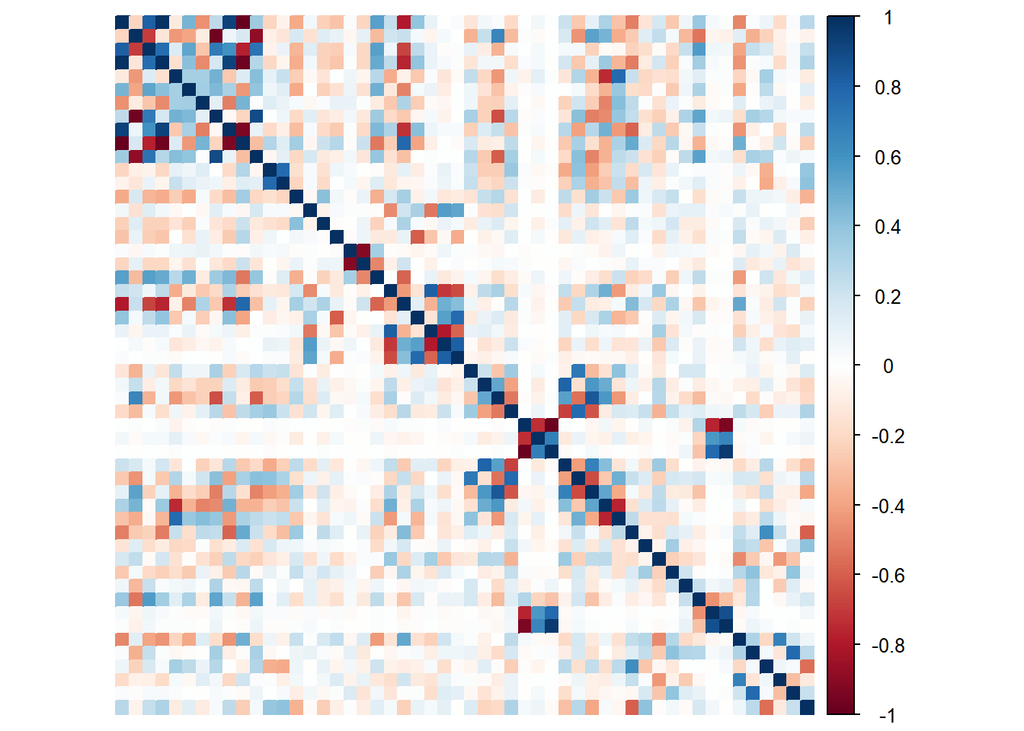

```r
data_corr <- select_if(train, is.numeric)
corrplot(
  cor(data_corr),
  method="color",
  tl.pos = "n",
  insig = "blank"
)
```

Our correlation plot shows that most of our data is not correlated with very few exceptions. As we are using Random Forest method to train our data, highly correlated variables may result in inaccurate predictions.

# Predictions

I will be using the random forest method to train our data because it’s flexible and provides high accuracy predictions through cross-validation. First we need to setup parallel processing so as to ensure fast processing of data.

```r
cl <- makeCluster(detectCores()-1)
registerDoParallel(cl)
```

Now we will start training the data. First we will set the k-folds to 7 using the trainControl() function. Also we will set allowParallel to be True for parallel processing.

```r
set.seed(2021)
fitcontrol <- trainControl(method = "cv", number = 7, allowParallel = T)
rf.fit <- train(classe~., method= "rf", data= train, trControl= fitcontrol)
stopCluster(cl)
registerDoSEQ()

#save model into RDS format to save time
saveRDS(rf.fit, file = "rfmodel.rds")
```

## Model Performance

Now we check our model performance.

```r
model.rf <- readRDS(file = "rfmodel.rds")
model.rf
```

```
## Random Forest
##
## 13737 samples
##    52 predictor
##     5 classes: 'A', 'B', 'C', 'D', 'E'
##
## No pre-processing
## Resampling: Cross-Validated (7 fold)
## Summary of sample sizes: 11774, 11774, 11776, 11775, 11774, 11776, ...
## Resampling results across tuning parameters:
##
##   mtry  Accuracy   Kappa
##    2    0.9929389  0.9910672
##   27    0.9921382  0.9900546
##   52    0.9863865  0.9827784
##
## Accuracy was used to select the optimal model using the largest value.
## The final value used for the model was mtry = 2.
```

From the result, we see that the optimal model, has an accuracy of 0.99.

```r
model.rf$finalModel
```

```
##
## Call:
##  randomForest(x = x, y = y, mtry = min(param$mtry, ncol(x)))
##                Type of random forest: classification
##                      Number of trees: 500
## No. of variables tried at each split: 2
##
##         OOB estimate of  error rate: 0.66%
## Confusion matrix:
##      A    B    C    D    E  class.error
## A 3903    3    0    0    0 0.0007680492
## B   16 2638    4    0    0 0.0075244545
## C    0   21 2372    3    0 0.0100166945
## D    0    0   36 2215    1 0.0164298401
## E    0    0    3    4 2518 0.0027722772
```

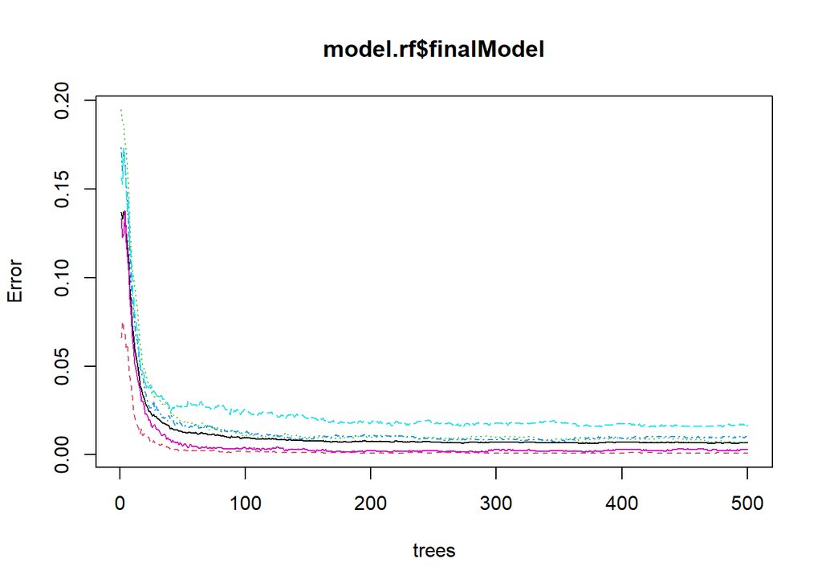

```r
plot(model.rf$finalModel)
```

## Variable Importance

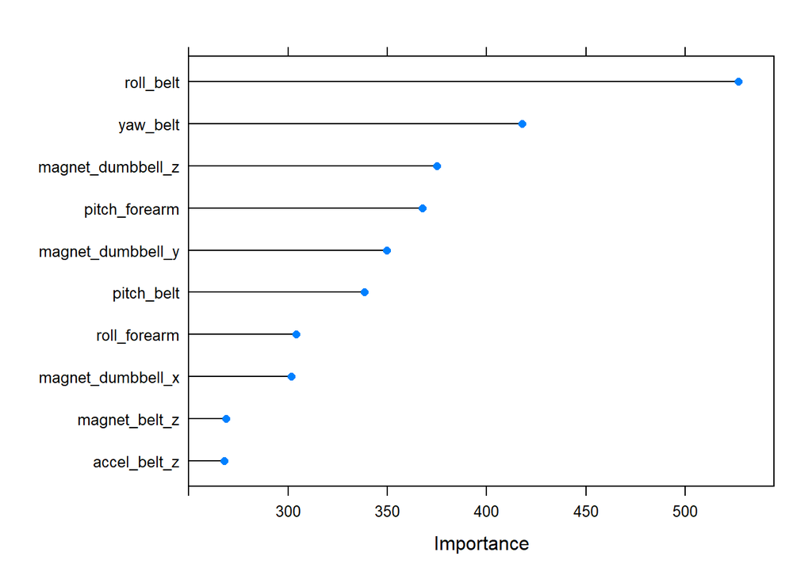

```r
importance <- varImp(model.rf, scale=F)
plot(importance, top=10)
```

## Prediction on validation test set

Using our trained model, we can apply on the validation set to observe the accuracy.

```r
pred.df <- predict(model.rf, validation)
confMAtrix <- confusionMatrix(validation$classe, pred.df)
confMAtrix$table
```

|  | A | B | C | D | E |
| --- | --- | --- | --- | --- | --- |
| A | 1673 | 1 | 0 | 0 | 0 |
| B | 9 | 1130 | 0 | 0 | 0 |
| C | 0 | 8 | 1017 | 1 | 0 |
| D | 0 | 0 | 15 | 948 | 1 |
| E | 0 | 0 | 3 | 2 | 1077 |

```r
confMAtrix$overall["Accuracy"]
```

```
##  Accuracy
## 0.9932031
```

```r
final_pred.df <- predict(model.rf, test_clean)
summary(final_pred.df)
```

```
## A B C D E
## 7 8 1 1 3
```

```r
final_pred.df
```

```
##  [1] B A B A A E D B A A B C B A E E A B B B
## Levels: A B C D E
```

# Citations

Ugulino, W.; Cardador, D.; Vega, K.; Velloso, E.; Milidiu, R.; Fuks, H. Wearable Computing: Accelerometers’ Data Classification of Body Postures and Movements. Proceedings of 21st Brazilian Symposium on Artificial Intelligence. Advances in Artificial Intelligence - SBIA 2012. In: Lecture Notes in Computer Science. , pp. 52-61. Curitiba, PR: Springer Berlin / Heidelberg, 2012. ISBN 978-3-642-34458-9. DOI: 10.1007/978-3-642-34459-6_6.